# R Studio and R Markdown for Reproducible Data Analysis

### 4.1.1 Presenting data nicely

If you noticed, when we printed out data from the `iris` dataset, the raw R output is not the most organized/nicest to look at. There are several packages and functions that we can use to format R data into tables for your reports, including:

- `knitr`’s `kable()` function
- `xtable`
- `stargazer`

The outputs look slightly different, you can test out which you prefer. Today we’ll use `kable()` - let’s put the function around the code we use to print out data and see what a difference it makes, like this example below:

```r
#raw R output
summary(iris)
```

```
##   Sepal.Length    Sepal.Width     Petal.Length    Petal.Width
##  Min.   :4.300   Min.   :2.000   Min.   :1.000   Min.   :0.100
##  1st Qu.:5.100   1st Qu.:2.800   1st Qu.:1.600   1st Qu.:0.300
##  Median :5.800   Median :3.000   Median :4.350   Median :1.300
##  Mean   :5.843   Mean   :3.057   Mean   :3.758   Mean   :1.199
##  3rd Qu.:6.400   3rd Qu.:3.300   3rd Qu.:5.100   3rd Qu.:1.800
##  Max.   :7.900   Max.   :4.400   Max.   :6.900   Max.   :2.500
##        Species
##  setosa    :50
##  versicolor:50
##  virginica :50
##
##
##
```

```r
#nice table format
kable(summary(iris))
```

|  | Sepal.Length | Sepal.Width | Petal.Length | Petal.Width | Species |
| --- | --- | --- | --- | --- | --- |
|  | Min. :4.300 | Min. :2.000 | Min. :1.000 | Min. :0.100 | setosa :50 |
|  | 1st Qu.:5.100 | 1st Qu.:2.800 | 1st Qu.:1.600 | 1st Qu.:0.300 | versicolor:50 |
|  | Median :5.800 | Median :3.000 | Median :4.350 | Median :1.300 | virginica :50 |
|  | Mean :5.843 | Mean :3.057 | Mean :3.758 | Mean :1.199 | NA |
|  | 3rd Qu.:6.400 | 3rd Qu.:3.300 | 3rd Qu.:5.100 | 3rd Qu.:1.800 | NA |
|  | Max. :7.900 | Max. :4.400 | Max. :6.900 | Max. :2.500 | NA |

## 4.2 Code chunk options

We can modify how we want to see the output of a code chunk in the final knitted file using code chunk options. You can take a look at all of the options in the [R Markdown Cheatsheet](https://rmarkdown.rstudio.com/lesson-15.html).

`eval` tells the program whether or not to evaluate a code chunk, i.e. run it when knitting, and by default is set to `TRUE`. Setting it to `FALSE` can be useful in cases where you want to show the code that you used, but do not want it to be re-run every time you knit because it may be a time consuming step.

```r
ggplot(iris, aes(x = Petal.Length, y = Petal.Width, col = Species)) +
  geom_point()
```

`echo` determines whether the R code is printed in the knitted file or not. Sometimes you just want to show the output (ie a plot), but don’t want all of the code used to generate it in your report.

Petal characteristics from the Iris dataset:

| Species | mean.length | mean.width |
| --- | --- | --- |
| setosa | 1.462 | 0.246 |
| versicolor | 4.260 | 1.326 |
| virginica | 5.552 | 2.026 |

`fig.width` and `fig.height` allow you to specify the dimensions (in inches) of plots within a code chunk in the knitted reports. We can make the previous plot bigger by altering these.

Same plot but larger:

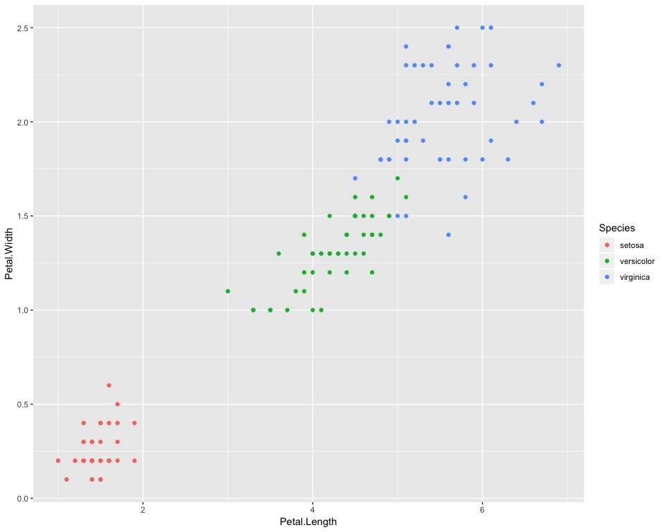

`warning` and `message` will specify whether we want to display any warnings or messages from running code.

You can also name your code chunks by writing the name after the `r` but before the `,` specifying the rest of the chunk options. This is mostly just useful in R Studio as you can navigate to different chunks using the guide at the bottom left of the Source screen. We can see this if we add some names to the chunks we made. *Beware*: you must use unique names for every code chunk in the document, otherwise you will get errors when trying to knit.

### 4.2.1 Global chunk options

If the same options will be used for many of your code chunks, we can set up global options that will apply to all chunks in the document

```r
knitr::opts_chunk$set(fig.width = 8)
```

## 4.3 In-line R code

If you ever want to run code within a line of text, like for example, I want to say in my report that the standard deviation in petal width in the setosa species of the iris dataset is 0.1053856.

Similar to code chunk, if we type `Ctrl+Enter` on the line of code, we can run it in the console.

R Markdown will not show the code used to generate the output for in-line code, and the output will be formatted so that it looks exactly like text.

## 4.4 Text formatting

Adding formatted text to an R Markdown document allows you to annotate what you are doing, summarize/organize findings, and give additional information. Everything outside of a code chunk is text, and it can be formatted following markdown rules. See the [R Markdown Cheatsheet](https://rmarkdown.rstudio.com/lesson-15.html) for a summary of useful formatting guidelines. Some common useful functonalities:

### 4.4.1 Headers

Using `#` defines headings, and these can be organized into subheadings using `##`, `###` and so on. These are extremely useful for organizing your code/analysis into sections. Let’s add some organization to our iris file using the following headers:

- Set-up
  - Load libraries
  - Load data
  - Explore the dataset
- Explore Iris data by species
  - Sepal measurements
  - Petal measurements

Additionally, for the html report output, you can also specify in certain sections to have subheadings appear as tabs using the `{.tabset}` option. For example, When we add this to the “Explore Iris data by species” section, the individual sepal and petal summaries/plots appear as tabs:

#### 4.4.1.1 Explore Iris data by species

##### 4.4.1.1.1 Sepal measurements

| Species | mean.length | mean.width |
| --- | --- | --- |
| setosa | 5.006 | 3.428 |
| versicolor | 5.936 | 2.770 |
| virginica | 6.588 | 2.974 |

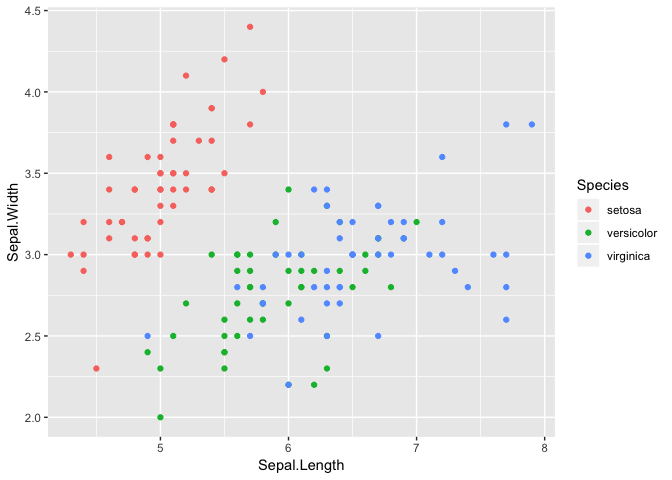

##### 4.4.1.1.2 Petal measurements

| Species | mean.length | mean.width |
| --- | --- | --- |
| setosa | 1.462 | 0.246 |
| versicolor | 4.260 | 1.326 |
| virginica | 5.552 | 2.026 |

### 4.4.2 Text edits

There are a number of other ways to format text, all summarized in the cheatsheet, including:

- `*i* or _i_` to *italicize* and `**b** or __b__` to **bold** text
- `^ss^` to create <sup>superscript</sup>
- `~~st~~` to strikethrough

Block quotes are specified by adding a `>` before a new line of text.

> While generally for quotes, these can also be useful if you want to highlight something of importance

### 4.4.3 Hyperlinks

Adding hyperlinks to text is a useful tool in R Markdown, particularly if in your report you would like to refer to external online sources (ie “I downloaded my data from XXX”). This is done by encasing the text you want in square brackets `[]` followed by the link encased in brackets `()` like this link to our [TOG website](https://bcchr.ca/tog)

### 4.4.4 Lists & tables

Generating bulleted lists can be done using `tab` and `*` or `+`. Numbered lists are generated using numbers after the tab.

**For example: The `iris dataset contains measurements for three species:**

```
  + iris versicolor
  + iris virginica
  + iris setosa
      * sub-species A?
      * sub-species B?
```

becomes

- iris versicolor
- iris virginica
- iris setosa
  - sub-species A?
  - sub-species B?

OR

1. iris versicolor
2. iris virginica
3. iris setosa
   - sub-species A?
   - sub-species B?

If you want to organize text into tables, use `|` to define the end of each cell (defines columns), `----` to define the header, and use enter to define every new line as a new row.

**For example, this table summarizing the N’s for each species (using some in-line r code too!)**

```
Species | N
--------|-----
iris versicolor | 50
iris virginica | 50
iris setosa | 50
```

becomes:

| Species | N |
| --- | --- |
| iris versicolor | 50 |
| iris virginica | 50 |
| iris setosa | 50 |

## 4.5 Modifying the report using metadata

A few simple additions to the metadata section at the beginning of the .Rmd file can add/alter some features of the knitted output file to enhance your report. Be careful about the formatting when you add these in, as they have to appear in the correct order; the below options will all go below the `output: html:` option.

### 4.5.1 Table of contents

You can add a table of contents in your knitted .rmd file by specifying `toc: true` in the medatata header. The TOC will be based off of the headers that you created throughtout in the .Rmd file. Let’s see how it works in our current file by altering the metadata as such:

```
---
title: Intro to R markdown
output:
  html_document:
    toc: true
---
```

We can also specify how many levels/subsections to display using `toc_depth: n`.

For the HTML outputs, you can also have the header “float”, ie be visible as we scroll through the document, using `toc_float: true`.

### 4.5.2 Section numbering

Adding `number_sections: true` specifies that the sections should be numbered in the output file.

### 4.5.3 Figure formatting

In addition to setting it up in the global chunk options, you can also specify figure options (`fig_height`, `fig_width`, `fig_caption`) for the output file in the header. These are applicable for both the HTML and PDF output options.

### 4.5.4 Themes

For HTML files, you can modify the theme of the output document using the `theme:` argument. The possible themes are pulled from the [Bootswatch](https://bootswatch.com/3/) theme library, or you can make your own. Let’s test this out by changing our documents to one of the following theme examples (your choice, or test a few!): darkly, readable, sandstone, united.

# 5 Tips for writing reproducible R code

Before we wrap up today, I wanted to leave you with a few quick tips on writing reproducible R code. Not only is writing clear and concise code useful for yourself when you have to go back to see what you’ve done, or re-run an analysis with altered parameters; but it ensures that others are able to take your code and reproduce your analysis, which is crucial for open and transparent science. These are by no means the end-all, but are a few things to keep in mind, particularly for those beginning to write code and analyze data in R:

1. **Clearly outline required inputs**: ensure you show which packages, input data etc. is required to perform the analysis, and load it using R commands rather than pressing buttons in R Studio.
2. **Keep all your source/input files in the same directory**: It is helpful to keep all files related to your analysis in one directory. This is also useful for your code, as you can specify the working directory (using `setwd()`) early on in your code, and instead of always writing lengthly paths to files (ie `dat <- read.table(Z:/Giulia/Volunteering/TOG/StudyGroup_tutorials/input_data.txt)`), if I have already set my working directory to the `StudyGroup_tutorials` folder early on, I can just call on the file using its name (ie `dat <- read.table(input_data.txt)`)
3. **Use descriptive and concise names**: When naming objects, make it clear what the object is, and use names that will be easy to call upon. For example, if I wanted to subset the `iris` data frame into three separate data frames for the three different species: using `d1`, `d2`, `d3` is not quite descriptive enough, while `iris_subset_setosa` etc. might get lenghthly to write out each time I use the data frame. Something simple like `setosa`, `virginica`, `versicolor` get the idea across clearly.
4. **Keep everything in order**: Even though you can run various lines of code from anywhere in an .R script or .Rmd document, code is meant to be read/run from top to bottom. Especially when knitting a document, we want to ensure that all elements of our code are kept in order.
5. **Separate distinct sections of your code**: Separating out distinct parts of your code helps to organize your code so that it is easy for you and others to navigate through. You can do this using code chunks, or `#` or `#---` within a code chunk.
6. **Make your lines of code easy to read and follow**: A big part of having your code be reproducible by someone else is that they should be able to easily read it and understand what you did. Having long lines of code with various functions embedded within gets messy and confusing. Use indentation to separate out different aspects of the line of code and to keep it from getting too long. For example:

```r
#messy, long line of code:
iris %>% group_by(Species) %>% summarize(mean.petal.length = mean(Petal.Length), mean.petal.width = mean(Petal.Width), mean.sepal.length = mean(Sepal.Length), mean.sepal.width = mean(Sepal.Width))

#easier to read line, separated by functions and using indentation to keep from getting too long
iris %>%
  group_by(Species) %>%
  summarize(mean.petal.length = mean(Petal.Length),
            mean.petal.width = mean(Petal.Width),
            mean.sepal.length = mean(Sepal.Length),
            mean.sepal.width = mean(Sepal.Width))
```

7. **Don’t save your session history!**: By default, R will ask if you want to save your current session to .RData. It is highly recommended not to do so. Instead, you should start with a new, clean environment every time you start a new R session. Not only can it be time consuming to load an old session if you are working with big data, but if you work with old objects in your environment, you could get different results when running your code!

*Does anyone have any other suggestions for tips that we can add to this list??*